# Hutch - Data Analysis Assessment

## Business Context

Hutch Sri Lanka launched a new online shop for their **broadband and mobile customers** which is doing well. Now, the management needs **detailed insights** on how to make the most money, understand what customers are buying, check how fast deliveries are, and see which products are most profitable.

## Analytical Questions

1. Revenue Optimization & Product Profitability Question: Which product categories and regions generate the highest profit margin percentages (profit_margin / total_amount), and how does the applied discount impact this profitability across different payment methods?
   - category, region, profit_margin, total_amount, discount, payment_method.
2. Customer Behavior & Segmentation Question: Are there specific customer age and gender segments (customer_age, customer_gender) that show a significantly higher average quantity of items purchased or a lower returned rate for the high-profit categories, indicating a key target audience for retention efforts?
   - customer_age, customer_gender, quantity, returned, category.
3. Delivery Performance & Customer Satisfaction Question: Which combination of region and category has the longest average delivery_time_days, and is this correlated with a higher return rate (returned = ‘Yes’), pointing to critical logistics issues impacting customer experience?
   - region, category, delivery_time_days, returned.

# Load Data Set and Libraries

```r
library(dplyr)
library(tidyr)
library(lubridate)
library(ggplot2)
library(ggcorrplot)
```

```r
df <- read.csv("Data Set.csv")
```

[output not shown]

The data set does not have any NULL values.

```r
sum(is.na(df))
```

```
[1] 0
```

[output not shown]

# Identify Drivers

## Sales Drivers

- Total Revenue: The total_amount column. This is crucial for revenue optimization.
- Total Profit: The profit_margin column. This is crucial for product profitability.
- Quantity Sold: The quantity column. This indicates demand.

```r
plot_categorical_features <- function(df, group_var,
                                      mean_total_thresh = 200,
                                      mean_profit_thresh = 30) {
  group_var <- rlang::ensym(group_var)

  # ---- Summarize once ----
  df_summary <- df %>%
    group_by(!!group_var) %>%
    summarise(
      mean_total = mean(total_amount, na.rm = TRUE),
      mean_profit = mean(profit_margin, na.rm = TRUE),
      mean_quantity = mean(quantity, na.rm = TRUE)
    ) %>%
    arrange(desc(mean_total))

  # ---- Common aesthetics ----
  common_theme <- theme_minimal() +
    theme(
      legend.position = "none",
      plot.title = element_text(size = 13, face = "bold")
    )

  # ---- Plot 1: Mean Total ----
  p1 <- ggplot(df_summary, aes(x = reorder(!!group_var, mean_total), y = mean_total,
                               fill = mean_total > mean_total_thresh)) +
    geom_col() +
    scale_fill_manual(values = c("TRUE" = my_theme$orange, "FALSE" = my_theme$blue)) +
    coord_flip() +
    labs(
      title = paste("Average Total Amount by", rlang::as_string(group_var)),
      x = rlang::as_string(group_var),
      y = "Mean Total Amount"
    ) +
    common_theme

  # ---- Plot 2: Mean Profit ----
  p2 <- ggplot(df_summary, aes(x = reorder(!!group_var, mean_profit), y = mean_profit,
                               fill = mean_profit > mean_profit_thresh)) +
    geom_col() +
    scale_fill_manual(values = c("TRUE" = my_theme$orange, "FALSE" = my_theme$blue)) +
    coord_flip() +
    labs(
      title = paste("Average Profit Margin by", rlang::as_string(group_var)),
      x = rlang::as_string(group_var),
      y = "Mean Profit Margin"
    ) +
    common_theme

  # ---- Plot 3: Mean Quantity ----
  p3 <- ggplot(df_summary, aes(x = reorder(!!group_var, mean_quantity), y = mean_quantity)) +
    geom_col(fill = my_theme$blue) +
    coord_flip() +
    labs(
      title = paste("Average Quantity by", rlang::as_string(group_var)),
      x = rlang::as_string(group_var),
      y = "Mean Quantity"
    ) +
    common_theme

  # ---- Plot 4: Category Contributions ----
  df_long <- df_summary %>%
    pivot_longer(
      cols = c(mean_total, mean_profit, mean_quantity),
      names_to = "metric",
      values_to = "value"
    ) %>%
    mutate(
      metric = recode(metric,
        mean_total = "Mean Total Amount",
        mean_profit = "Mean Profit Margin",
        mean_quantity = "Mean Quantity"
      )
    ) %>%
    group_by(metric) %>%
    mutate(
      contribution = value / sum(abs(value), na.rm = TRUE)  # <-- scaled within each metric
    ) %>%
    ungroup()

  # Consistent order for group variable
  category_order <- df_long %>%
    group_by(!!group_var) %>%
    summarise(total_contribution = sum(contribution, na.rm = TRUE)) %>%
    arrange(desc(total_contribution)) %>%
    pull(!!group_var)

  df_long <- df_long %>%
    mutate(
      !!group_var := factor(!!group_var, levels = category_order),
      metric = factor(
        metric,
        levels = c("Mean Quantity", "Mean Total Amount", "Mean Profit Margin")
      )
    )

  p4 <- ggplot(df_long, aes(x = contribution, y = metric, fill = !!group_var)) +
    geom_col(width = 0.6, alpha = 0.9) +
    scale_x_continuous(labels = scales::percent_format(accuracy = 1)) +
    scale_fill_brewer(palette = "Set3") +
    labs(
      title = "Category Contributions to Average Metrics",
      x = "Category Contribution (%)",
      y = "",
      fill = rlang::as_string(group_var)
    ) +
    theme_minimal(base_size = 12) +
    theme(
      legend.position = "bottom",
      legend.title = element_text(size = 10),
      legend.text = element_text(size = 9),
      plot.title = element_text(size = 13, face = "bold"),
      axis.text.y = element_text(size = 11)
    )

  # ---- Return everything ----
  list(
    summary = df_summary,
    mean_total_plot = p1,
    mean_profit_plot = p2,
    mean_quantity_plot = p3,
    contribution_plot = p4
  )
}
```

### Grouped by Category

| category | mean_total | mean_profit | mean_quantity |
| --- | --- | --- | --- |
| Electronics | 537.08843 | 55.723587 | 1.511812 |
| Home | 196.40633 | 47.864717 | 1.499727 |
| Sports | 151.00109 | 38.485114 | 1.497003 |
| Fashion | 75.39907 | 20.597162 | 1.462744 |
| Beauty | 37.29451 | 11.990395 | 1.492079 |
| Toys | 31.08401 | 7.927773 | 1.486461 |
| Grocery | 20.20712 | -2.264160 | 1.486200 |

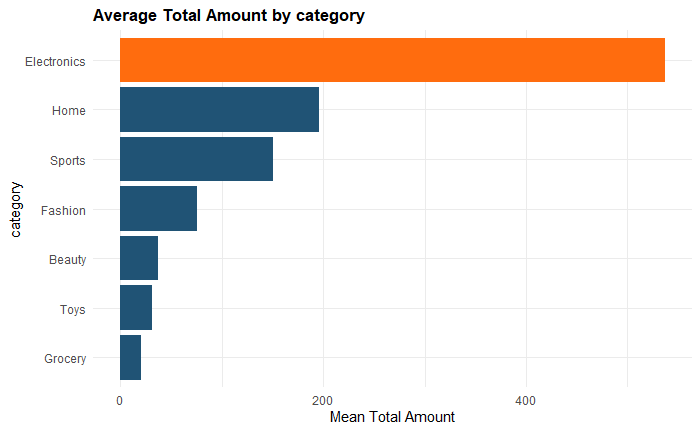

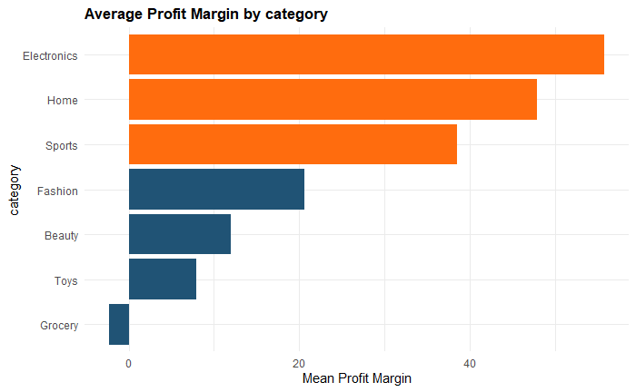

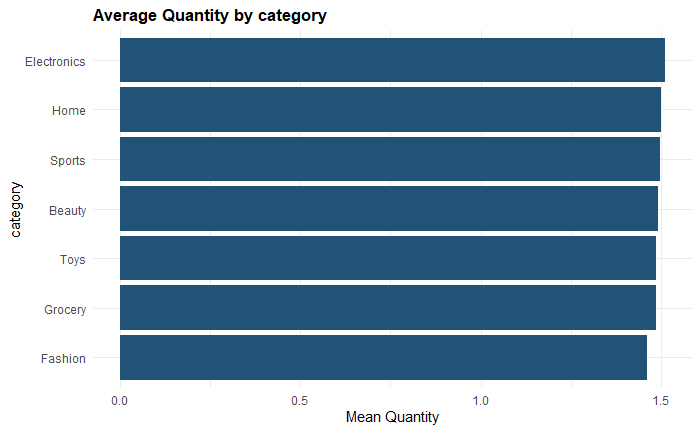

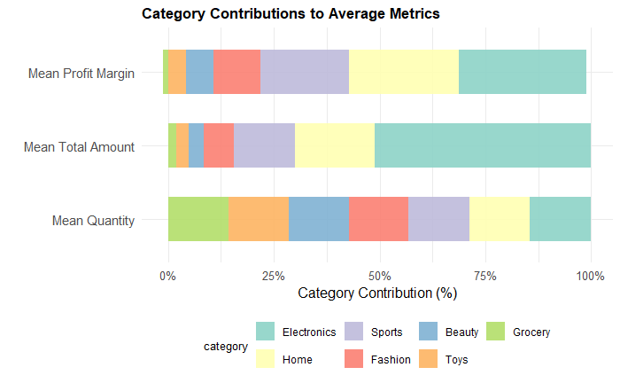

```r
df_category <- plot_categorical_features(df, category, mean_total_thresh = 200, mean_profit_thresh = 30)
df_category
```

### Grouped by Region

| region | mean_total | mean_profit | mean_quantity |
| --- | --- | --- | --- |
| West | 174.2583 | 28.99320 | 1.477526 |
| South | 171.1625 | 27.83243 | 1.489188 |
| East | 170.3845 | 28.24960 | 1.502752 |
| Central | 166.9928 | 28.05818 | 1.490057 |
| North | 166.9319 | 27.53481 | 1.493661 |

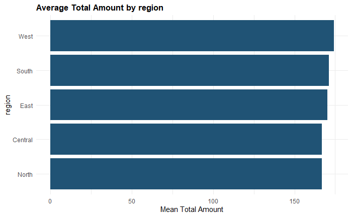

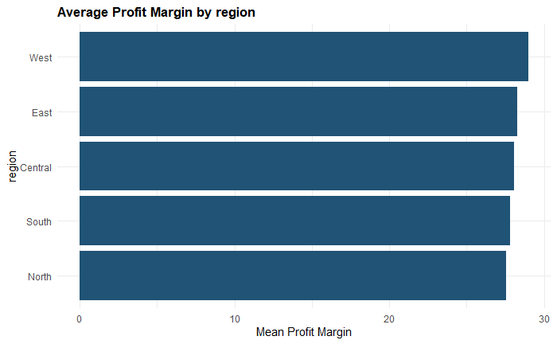

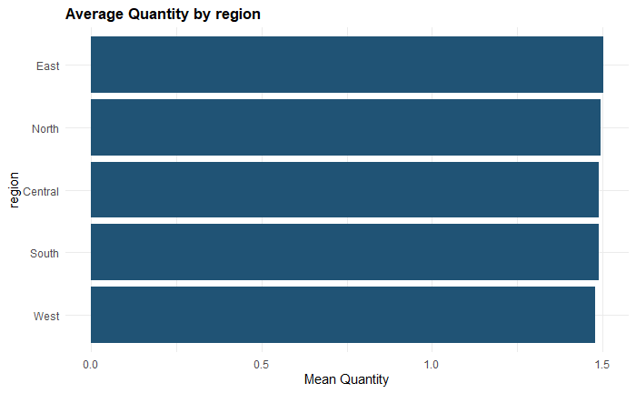

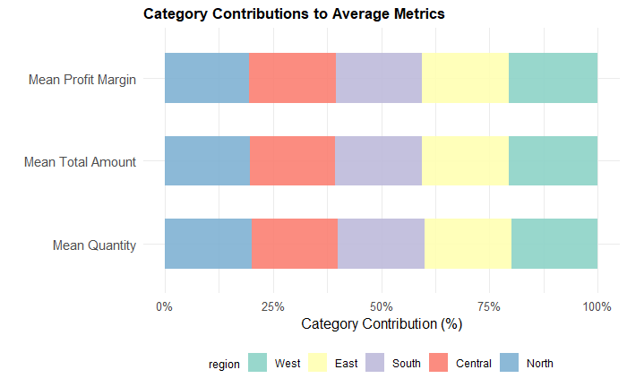

```r
df_region <- plot_categorical_features(df, region)
df_region
```

### Grouped by Payment Method

| payment_method | mean_total | mean_profit | mean_quantity |
| --- | --- | --- | --- |
| COD | 172.0125 | 27.93092 | 1.481490 |
| UPI | 171.7139 | 28.17693 | 1.512993 |
| Debit Card | 171.6885 | 28.34372 | 1.479248 |
| Credit Card | 169.0047 | 28.09320 | 1.498850 |
| PayPal | 167.3993 | 27.70462 | 1.475029 |
| Wallet | 165.8869 | 28.25723 | 1.490073 |

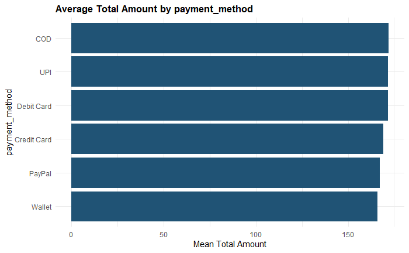

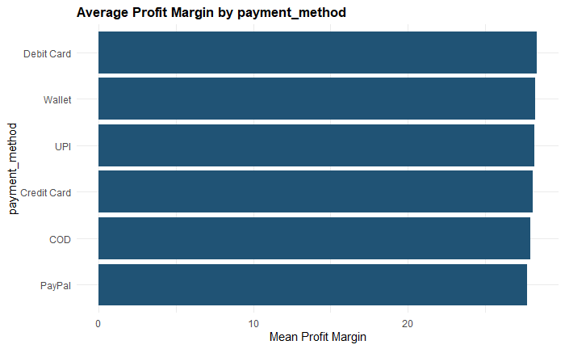

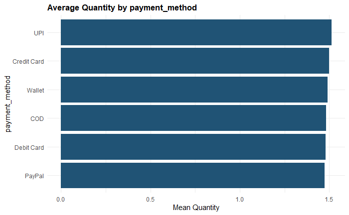

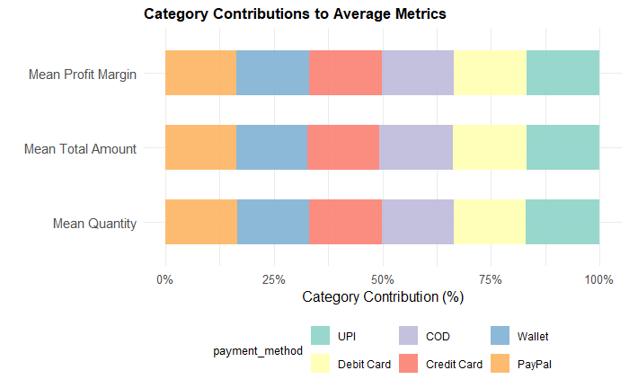

```r
df_payment_method <- plot_categorical_features(df, payment_method)
df_payment_method
```

### Grouped by Customer Gender

| customer_gender | mean_total | mean_profit | mean_quantity |
| --- | --- | --- | --- |
| Male | 171.2480 | 28.38973 | 1.487431 |
| Female | 169.6573 | 28.00368 | 1.497265 |
| Other | 159.5778 | 26.25143 | 1.449708 |

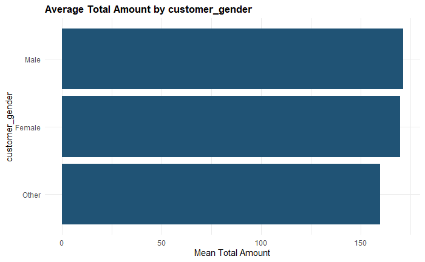

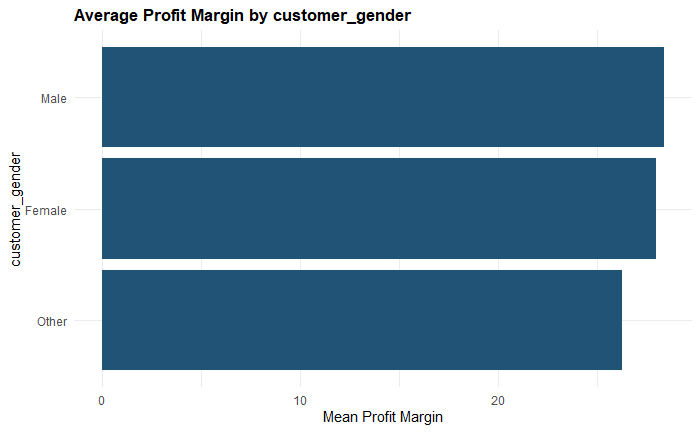

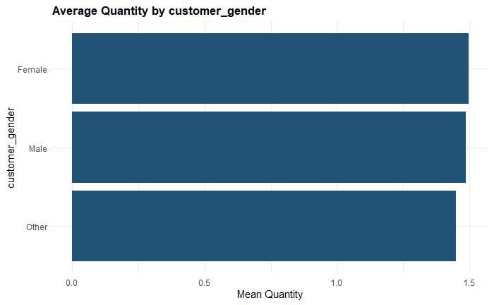

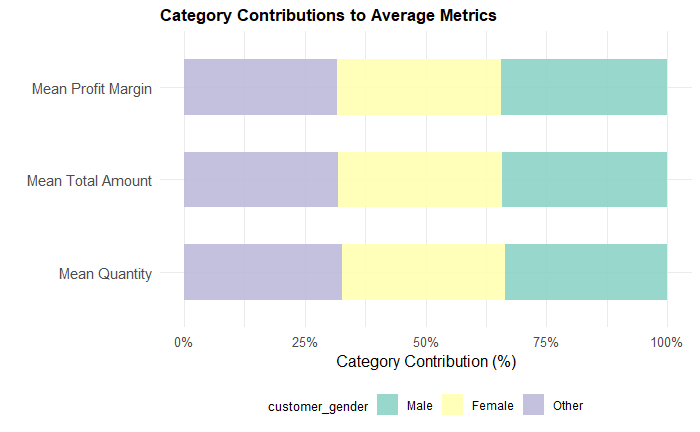

```r
df_gender <- plot_categorical_features(df, customer_gender)
df_gender
```

### Grouped by Discount

| discount | mean_total | mean_profit | mean_quantity |
| --- | --- | --- | --- |
| 0.00 | 178.9427 | 30.07137 | 1.494641 |
| 0.05 | 165.4809 | 27.46464 | 1.499190 |
| 0.10 | 161.6174 | 26.04126 | 1.487136 |
| 0.15 | 156.4273 | 24.95166 | 1.463685 |
| 0.20 | 145.6892 | 22.67058 | 1.478865 |
| 0.30 | 132.5305 | 19.42964 | 1.468750 |

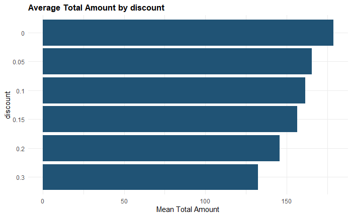

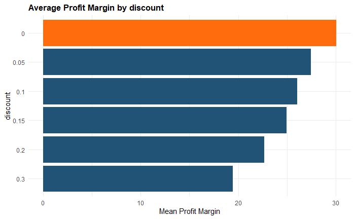

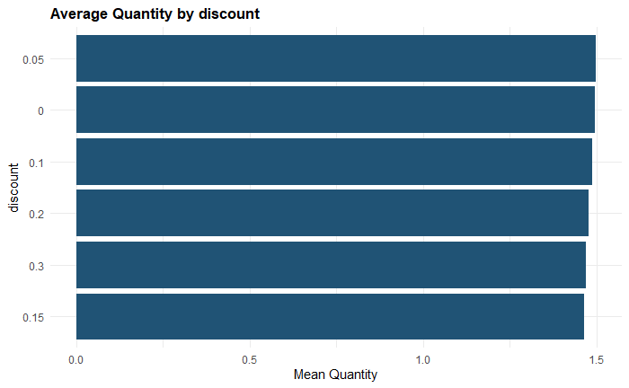

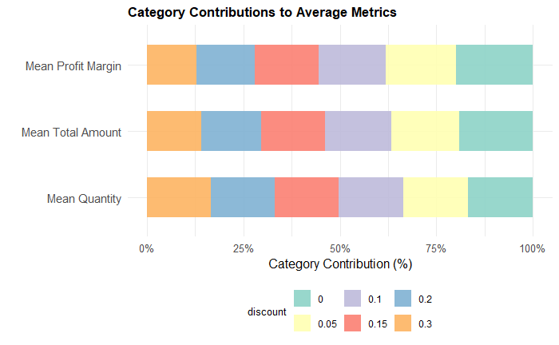

```r
df_discount <- plot_categorical_features(df, discount)
df_discount
```

### Grouped by Age

| age_group | mean_total | mean_profit | mean_quantity |
| --- | --- | --- | --- |
| Young Adults | 178.8212 | 29.41796 | 1.500944 |
| Middle-Aged | 171.3338 | 28.21053 | 1.482454 |
| Older Adults | 169.5633 | 27.97448 | 1.488640 |
| Seniors | 164.0043 | 27.42213 | 1.496049 |

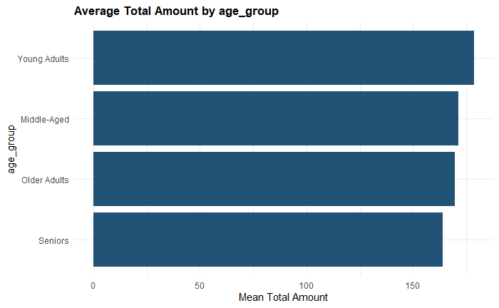

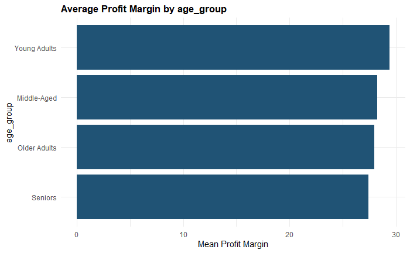

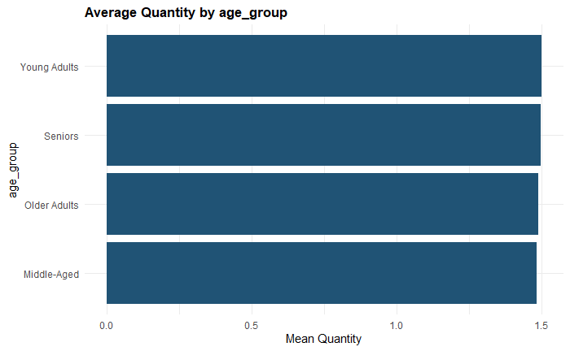

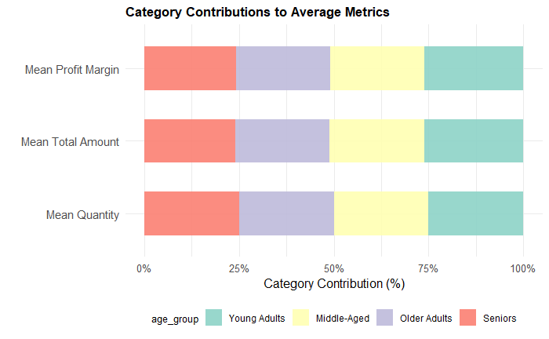

```r
df_age <- plot_categorical_features(df, age_group, mean_total_thresh = 200, mean_profit_thresh = 30)
df_age
```

### Grouped by Delivery Method

| delivery_method | mean_total | mean_profit | mean_quantity |
| --- | --- | --- | --- |
| Standard Delivery | 170.3207 | 28.24161 | 1.489070 |
| Slow Delivery | 169.1502 | 27.77261 | 1.495273 |

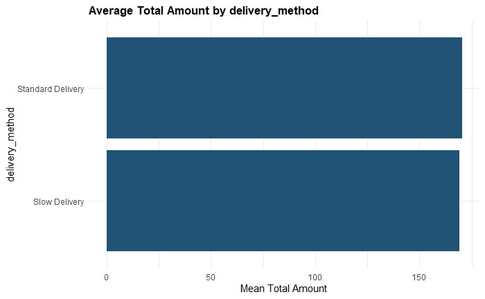

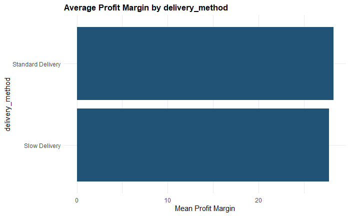

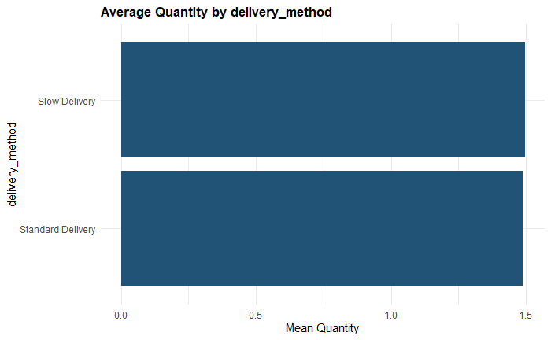

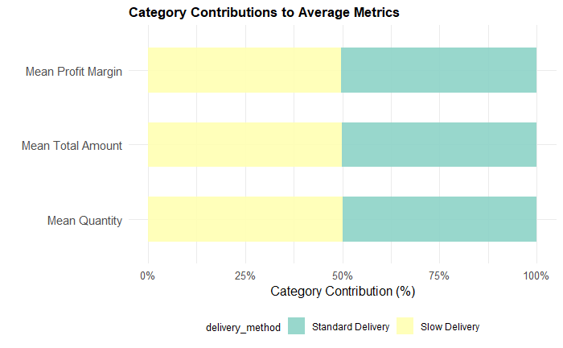

```r
df_delivery_method <- plot_categorical_features(df, delivery_method, mean_total_thresh = 200, mean_profit_thresh = 30)
df_delivery_method
```